# WP1: Data extraction

24/05/2021

This script incorporates the selection of relevant variables and cases for the research questions included in Work Package 1: *Identifying heterogeneity in reading comprehension difficulties using data collected from ALSPAC*. It also includes preliminary exploration and documentation of patterns of missingness in the key variables of interest, and splits the sample in two for calibration and validation purposes.

```r
# Note - no up-to-date version of packages with MCAR tests, install prev versions - use with caution
#devtools::install_version("MissMech", version="1.0.2", repos=getOption("repos")["CRAN"])
#devtools::install_version("mvnmle", version="0.1-11.1", repos=getOption("repos")["CRAN"])

library(data.table)
library(tidyverse)
library(readxl)
library(naniar)
library(MissMech)
library(finalfit)
library(broom)
library(psych)
library(WriteXLS)
library(knitr)
library(DiagrammeR)
library(cowplot)
library(kableExtra)

# Set seed for reproducibility
set.seed(25052021)
```

```r
# Create subdirectories for storing data files and output, if do not already exist
if(dir.exists("../output/")==FALSE){dir.create("../output/")}
if(dir.exists("../output/figures/")==FALSE){dir.create("../output/figures/")}
if(dir.exists("../output/figures/missingness/")==FALSE){dir.create("../output/figures/missingness/")}
if(dir.exists("../output/tables/")==FALSE){dir.create("../output/tables/")}
if(dir.exists("../output/analysis/")==FALSE){dir.create("../output/analysis/")}
if(dir.exists("../data/processed/")==FALSE){dir.create("../data/processed/")}
```

# Access statement

Under ALSPAC’s Data Access arrangements, we will receive all data associated with the grant at the beginning of the project. However, the grant incorporates a number of sub-projects (or work packages) that build on each other, making it challenging to specify all later hypotheses and analysis plans in advance.

We will pre-register each set of hypotheses and analyses prior to working with the data for each sub-project, and make clear in the pre-registration where analyses include variables that we have already interacted with. We will extract the relevant data for each sub-project only after it has been pre-registered, and work only with the relevant data for that sub-project.

The pre-registration for this sub-project can be found at https://osf.io/4zahf.

# Extracting data

### Rename variables

Read in and rename variables

```r
# Read in data
data_orig <- fread("../data/raw/B3153/Nation_19May21.csv") # ALSPAC data

# Read in codebook for renaming
codebook <- read_excel("../data/codebook.xlsx", sheet = "codebook") %>%
  filter(workbook != "education" | is.na(workbook)) %>%   # education data coming from separate database
  select(`Var name`, R_var_name)

# # List variables not in existing codebook
# setdiff(codebook$`Var name`, names(data_orig))
# setdiff(names(data_orig), codebook$`Var name`)
#
# # Extract variable info for updating codebook
# alspac_codebook <- read_excel("../data/raw/B3153/Variable information.xlsx", skip = 1) %>%
#   filter(!Variable %in% codebook$`Var name`)
# write.csv(alspac_codebook, "../data/raw/codebook_update.csv")

# Rename
data_named <- data_orig
names(data_named) <- codebook$R_var_name[match(names(data_named), codebook$`Var name`)]

# Create unique identifier per participant
data_named <- data_named %>%
  mutate(yp_id = paste0(cidB3153, qlet))
```

### Participant numbers

Summarise number of participants in dataset here, and when they were recruited to the sample. Store numbers in relation to NARA data availability, to document how we arrived at the subsample used in the present study.

```r
# Number of participants - minus triplets/quadruplets (n = 13 individuals)
nrow(data_named)
```

```
## [1] 15645
```

```r
# Number of pregnancies
length(unique(data_named$cidB3153))
```

```
## [1] 15443
```

```r
# Participants alive at 1 year (ALSPAC baseline group)
data_named %>%
  mutate(alive_1yr = ifelse(kz011b == -9999, "withdrawn",
                            ifelse(kz011b == 2, 0, kz011b))) %>%
  group_by(alive_1yr) %>%
  count()
```

```
## # A tibble: 3 x 2
## # Groups:   alive_1yr [3]
##   alive_1yr     n
##   <chr>     <int>
## 1 0           754
## 2 1         14869
## 3 withdrawn    22
```

```r
# Participants in core sample
data_named %>%
  mutate(in_core = ifelse(in_core == -9999, "withdrawn",
                            ifelse(in_core == 2, 0,
                                   ifelse(in_core == -1, "birth outcome not known", in_core)))) %>%
  group_by(in_core) %>%
  count()
```

```
## # A tibble: 4 x 2
## # Groups:   in_core [4]
##   in_core                     n
##   <chr>                   <int>
## 1 0                         912
## 2 1                       14642
## 3 birth outcome not known    69
## 4 withdrawn                  22
```

```r
# Core sample alive at 1 year (ALSPAC baseline group)
data_named %>%
  filter(in_core == 1) %>%
  mutate(alive_1yr = ifelse(kz011b == -9999, "withdrawn",
                            ifelse(kz011b == 2, 0, kz011b))) %>%
  group_by(alive_1yr) %>%
  count()
```

```
## # A tibble: 2 x 2
## # Groups:   alive_1yr [2]
##   alive_1yr     n
##       <dbl> <int>
## 1         0   685
## 2         1 13957
```

```r
# Participants enrolled as part of phase 2, during focus@7
data_named %>%
  mutate(in_phase2 = ifelse(in_phase2 == -9999, "withdrawn",
                            ifelse(in_phase2 == 2, 0,
                                   ifelse(in_phase2 == -1, "birth outcome not known", in_phase2)))) %>%
  group_by(in_phase2) %>%
  count()
```

```
## # A tibble: 3 x 2
## # Groups:   in_phase2 [3]
##   in_phase2     n
##   <chr>     <int>
## 1 0         15168
## 2 1           455
## 3 withdrawn    22
```

```r
# Participants enrolled as part of phase 3, between focus@7 and age 18
data_named %>%
  mutate(in_phase3 = ifelse(in_phase3 == -9999, "withdrawn",
                            ifelse(in_phase3 == 2, 0,
                                   ifelse(in_phase3 == -1, "birth outcome not known", in_phase3)))) %>%
  group_by(in_phase3) %>%
  count()
```

```
## # A tibble: 3 x 2
## # Groups:   in_phase3 [3]
##   in_phase3     n
##   <chr>     <int>
## 1 0         15361
## 2 1           262
## 3 withdrawn    22
```

```r
# Participants attended F09 - matches the sample size reported in data dictionary
data_named %>%
  mutate(in_core = ifelse(in_core == -9999, "withdrawn",
                          ifelse(in_core == 2, 0,
                                 ifelse(in_core == -1, "birth outcome not known", in_core)))) %>%
  group_by(in_f09, in_core) %>%
  count()
```

```
## # A tibble: 7 x 3
## # Groups:   in_f09, in_core [7]
##   in_f09 in_core                     n
##    <int> <chr>                   <int>
## 1      0 0                         505
## 2      0 1                        7342
## 3      0 birth outcome not known    69
## 4      0 withdrawn                   7
## 5      1 0                         407
## 6      1 1                        7300
## 7      1 withdrawn                  15
```

```r
# THE PRESENT STUDY (for use in flowchart)

attended_f09 <- data_named %>%
  filter(in_f09 == 1) %>%
  count()

# NARA data
nara_avail <- data_named %>%
  filter(nara_comp_std_f9 > 0) %>%
  count()

nara_withd <- data_named %>%
  filter(nara_comp_std_f9 == -9999) %>%
  count()

nara_sess <- data_named %>%
  filter(nara_comp_std_f9 == -9) %>%
  count()

nara_oakh <- data_named %>%
  filter(nara_comp_std_f9 == -8) %>%
  count()

nara_no <- data_named %>%
  filter(nara_comp_std_f9 == -1) %>%
  count()
```

### WP1 Variables

Specify variables to be used in these analyses.

```r
# Variables for pre-registered analyses
RQ1 <- c("age_m_f8", "age_m_f9",                                       # age
         "read_word_raw_f9", "read_nonw_raw_f9", "nara_acc_raw_f9",    # accuracy
         "nara_comp_raw_f9", "wold_comp_raw_f8")                       # comprehension

RQ2 <- c("age_m_f10",                                                # age
         "nara_rate_raw_f9",                                         # fluency
         "wold_vcb_strt_f8", "wold_vcb_i1_f8", "wold_vcb_i2_f8", "wold_vcb_i3_f8", "wold_vcb_i4_f8", "wold_vcb_i5_f8",
         "wold_vcb_i6_f8", "wold_vcb_i7_f8", "wold_vcb_i8_f8", "wold_vcb_i9_f8", "wold_vcb_i10_f8",  "wisc_vcb_raw_f8",     # vocabulary
         "wisc_pcmp_raw_f8", "wisc_code_raw_f8", "wisc_parr_raw_f8", "wisc_bloc_raw_f8", "wisc_obja_raw_f8",  # nonverbal ability
         "wisc_bwsp_raw_f8", "cntsp_span_raw_f10",                     # working memory
         "teach_slct_raw_f8", "teach_divd_raw_f8", "teach_ctrs_raw_f8", "teach_ctro_raw_f8", "sdq_hyp_prnt_ku") #attention

# Variables for descriptives, exploratory analyses (subject to change)
other <- c("yp_id", "cidB3153", "qlet",
           "sex", "age_m_ku",
           "nara_acc_std_f9", "nara_comp_std_f9", "nara_rate_std_f9", "nara_npass_f9",
           "wisc_vcb_std_f8",
           "wisc_pcmp_std_f8", "wisc_code_std_f8", "wisc_parr_std_f8", "wisc_bloc_std_f8", "wisc_obja_std_f8", "wisc_perf_std_f8")

# Additional variables for exploring missingness
missingness <-  c("ethn_c", "wght_birth", "gest_birth", "m_age_birth", "m_edu_c", "m_home_a", "mtcq_vcb_raw_kg")

# All variables for extraction
wp1_vars <- c(RQ1, RQ2, other, missingness)
```

Extract relevant variables (including all observations at this stage) and recode missing data values.

```r
# Extract relevant variables from dataset, and processing missing data
wp1_allobs <- data_named %>%

  # Select relevant variables
  select(all_of(wp1_vars)) %>%

  # Relabel missing data
  replace_with_na_at(.vars = wp1_vars[!wp1_vars %in% c("teach_divd_raw_f8", "teach_slct_raw_f8")],
                       condition = ~.x < 0) %>%
  replace_with_na(replace = list(teach_divd_raw_f8 = c(-9999, -103, -101, -2),     # specify manually for TEACh as true negatives
                                 teach_slct_raw_f8 = c(-9999, -103, -102, -101)))


# Inspect summary statistics and check that match up with expectations from data dictionary
describe(wp1_allobs) %>%
  round(., 2) %>%
  kable()
```

|  | vars | n | mean | sd | median | trimmed | mad | min | max | range | skew | kurtosis | se |
| --- | --- | --- | --- | --- | --- | --- | --- | --- | --- | --- | --- | --- | --- |
| age_m_f8 | 1 | 7479 | 103.83 | 3.92 | 103.00 | 103.07 | 1.48 | 89.00 | 127.00 | 38.00 | 2.42 | 6.79 | 0.05 |
| age_m_f9 | 2 | 7715 | 118.49 | 3.89 | 118.00 | 118.00 | 2.97 | 105.00 | 140.00 | 35.00 | 1.46 | 3.17 | 0.04 |
| read_word_raw_f9 | 3 | 7648 | 7.50 | 2.50 | 8.00 | 7.88 | 1.48 | 0.00 | 10.00 | 10.00 | -1.19 | 0.82 | 0.03 |
| read_nonw_raw_f9 | 4 | 7635 | 5.20 | 2.50 | 5.00 | 5.29 | 2.97 | 0.00 | 10.00 | 10.00 | -0.26 | -0.74 | 0.03 |
| nara_acc_raw_f9 | 5 | 6935 | 66.02 | 20.56 | 68.00 | 67.33 | 23.72 | 0.00 | 100.00 | 100.00 | -0.49 | -0.51 | 0.25 |
| nara_comp_raw_f9 | 6 | 6935 | 24.96 | 7.85 | 25.00 | 25.15 | 8.90 | 0.00 | 44.00 | 44.00 | -0.24 | -0.29 | 0.09 |
| wold_comp_raw_f8 | 7 | 7375 | 7.46 | 1.96 | 7.00 | 7.46 | 1.48 | 2.00 | 15.00 | 13.00 | 0.04 | 0.31 | 0.02 |
| age_m_f10 | 8 | 7550 | 127.78 | 3.18 | 127.00 | 127.32 | 2.97 | 118.00 | 147.00 | 29.00 | 1.84 | 5.28 | 0.04 |
| nara_rate_raw_f9 | 9 | 6916 | 80.68 | 27.71 | 79.00 | 79.55 | 28.17 | 14.00 | 394.00 | 380.00 | 0.85 | 4.35 | 0.33 |
| wold_vcb_strt_f8 | 10 | 7382 | 1.01 | 0.07 | 1.00 | 1.00 | 0.00 | 1.00 | 2.00 | 1.00 | 13.47 | 179.51 | 0.00 |
| wold_vcb_i1_f8 | 11 | 7342 | 1.03 | 0.16 | 1.00 | 1.00 | 0.00 | 1.00 | 2.00 | 1.00 | 5.94 | 33.26 | 0.00 |
| wold_vcb_i2_f8 | 12 | 7342 | 1.14 | 0.34 | 1.00 | 1.05 | 0.00 | 1.00 | 2.00 | 1.00 | 2.12 | 2.49 | 0.00 |
| wold_vcb_i3_f8 | 13 | 7342 | 1.20 | 0.40 | 1.00 | 1.13 | 0.00 | 1.00 | 2.00 | 1.00 | 1.48 | 0.20 | 0.00 |
| wold_vcb_i4_f8 | 14 | 7342 | 1.08 | 0.27 | 1.00 | 1.00 | 0.00 | 1.00 | 2.00 | 1.00 | 3.13 | 7.78 | 0.00 |
| wold_vcb_i5_f8 | 15 | 7342 | 1.05 | 0.22 | 1.00 | 1.00 | 0.00 | 1.00 | 2.00 | 1.00 | 4.09 | 14.73 | 0.00 |
| wold_vcb_i6_f8 | 16 | 7342 | 1.38 | 0.48 | 1.00 | 1.35 | 0.00 | 1.00 | 2.00 | 1.00 | 0.50 | -1.75 | 0.01 |
| wold_vcb_i7_f8 | 17 | 7342 | 1.31 | 0.46 | 1.00 | 1.27 | 0.00 | 1.00 | 2.00 | 1.00 | 0.80 | -1.36 | 0.01 |
| wold_vcb_i8_f8 | 18 | 7342 | 1.31 | 0.46 | 1.00 | 1.26 | 0.00 | 1.00 | 2.00 | 1.00 | 0.83 | -1.31 | 0.01 |
| wold_vcb_i9_f8 | 19 | 7342 | 1.50 | 0.50 | 2.00 | 1.50 | 0.00 | 1.00 | 2.00 | 1.00 | -0.02 | -2.00 | 0.01 |
| wold_vcb_i10_f8 | 20 | 7342 | 1.56 | 0.50 | 2.00 | 1.58 | 0.00 | 1.00 | 2.00 | 1.00 | -0.25 | -1.94 | 0.01 |
| wisc_vcb_raw_f8 | 21 | 7369 | 23.31 | 7.87 | 22.00 | 22.90 | 5.93 | 0.00 | 48.00 | 48.00 | 0.44 | -0.07 | 0.09 |
| wisc_pcmp_raw_f8 | 22 | 7370 | 15.73 | 4.65 | 16.00 | 15.98 | 2.97 | 0.00 | 30.00 | 30.00 | -0.50 | 0.10 | 0.05 |
| wisc_code_raw_f8 | 23 | 7402 | 34.52 | 7.45 | 35.00 | 34.43 | 7.41 | 0.00 | 99.00 | 99.00 | 0.37 | 3.41 | 0.09 |
| wisc_parr_raw_f8 | 24 | 7306 | 20.13 | 10.75 | 20.00 | 19.87 | 11.86 | 0.00 | 58.00 | 58.00 | 0.13 | -0.77 | 0.13 |
| wisc_bloc_raw_f8 | 25 | 7322 | 32.19 | 12.51 | 32.00 | 32.38 | 11.86 | 0.00 | 68.00 | 68.00 | -0.12 | -0.41 | 0.15 |
| wisc_obja_raw_f8 | 26 | 6981 | 23.96 | 8.40 | 25.00 | 24.27 | 10.38 | 0.00 | 44.00 | 44.00 | -0.24 | -1.08 | 0.10 |
| wisc_bwsp_raw_f8 | 27 | 7219 | 3.52 | 0.83 | 3.00 | 3.49 | 1.48 | 0.00 | 7.00 | 7.00 | 0.27 | 0.60 | 0.01 |
| cntsp_span_raw_f10 | 28 | 7005 | 3.42 | 0.85 | 3.50 | 3.42 | 0.74 | 0.00 | 5.00 | 5.00 | -0.41 | 0.84 | 0.01 |
| teach_slct_raw_f8 | 29 | 7182 | 5.21 | 1.93 | 4.86 | 4.97 | 1.28 | -4.06 | 46.58 | 50.64 | 4.36 | 55.21 | 0.02 |
| teach_divd_raw_f8 | 30 | 7045 | 5.67 | 16.10 | 1.80 | 2.68 | 2.92 | -34.09 | 270.89 | 304.98 | 7.58 | 76.76 | 0.19 |
| teach_ctrs_raw_f8 | 31 | 7206 | 13.11 | 3.05 | 12.50 | 12.79 | 2.22 | 7.00 | 91.00 | 84.00 | 4.38 | 71.69 | 0.04 |
| teach_ctro_raw_f8 | 32 | 7200 | 17.47 | 5.65 | 16.50 | 16.97 | 2.97 | 8.50 | 300.00 | 291.50 | 21.49 | 965.33 | 0.07 |
| sdq_hyp_prnt_ku | 33 | 8052 | 2.96 | 2.26 | 3.00 | 2.75 | 2.97 | 0.00 | 10.00 | 10.00 | 0.81 | 0.28 | 0.03 |
| yp_id* | 34 | 15645 | 7823.00 | 4516.47 | 7823.00 | 7823.00 | 5798.45 | 1.00 | 15645.00 | 15644.00 | 0.00 | -1.20 | 36.11 |
| cidB3153 | 35 | 15645 | 10652.09 | 6152.14 | 10670.00 | 10652.55 | 7925.98 | 1.00 | 21485.00 | 21484.00 | 0.00 | -1.20 | 49.19 |
| qlet* | 36 | 15645 | 1.01 | 0.11 | 1.00 | 1.00 | 0.00 | 1.00 | 2.00 | 1.00 | 8.61 | 72.07 | 0.00 |
| sex | 37 | 15039 | 1.49 | 0.50 | 1.00 | 1.49 | 0.00 | 1.00 | 2.00 | 1.00 | 0.05 | -2.00 | 0.00 |
| age_m_ku | 38 | 8204 | 115.82 | 1.57 | 115.00 | 115.45 | 0.00 | 114.00 | 132.00 | 18.00 | 3.09 | 14.28 | 0.02 |
| nara_acc_std_f9 | 39 | 6935 | 103.64 | 13.68 | 104.00 | 104.01 | 14.83 | 69.00 | 131.00 | 62.00 | -0.25 | -0.28 | 0.16 |
| nara_comp_std_f9 | 40 | 6935 | 99.87 | 11.90 | 100.00 | 100.00 | 13.34 | 69.00 | 131.00 | 62.00 | -0.12 | -0.06 | 0.14 |
| nara_rate_std_f9 | 41 | 6916 | 105.10 | 12.56 | 105.00 | 105.31 | 13.34 | 69.00 | 131.00 | 62.00 | -0.17 | -0.12 | 0.15 |
| nara_npass_f9 | 42 | 6950 | 4.53 | 0.82 | 5.00 | 4.69 | 0.00 | 0.00 | 6.00 | 6.00 | -1.78 | 3.50 | 0.01 |
| wisc_vcb_std_f8 | 43 | 7374 | 10.94 | 4.39 | 11.00 | 10.79 | 4.45 | 1.00 | 19.00 | 18.00 | 0.33 | -0.58 | 0.05 |
| wisc_pcmp_std_f8 | 44 | 7382 | 9.11 | 3.71 | 10.00 | 9.27 | 2.97 | 1.00 | 19.00 | 18.00 | -0.34 | -0.27 | 0.04 |
| wisc_code_std_f8 | 45 | 7401 | 10.50 | 3.05 | 11.00 | 10.54 | 2.97 | 1.00 | 19.00 | 18.00 | -0.13 | -0.15 | 0.04 |
| wisc_parr_std_f8 | 46 | 7307 | 9.42 | 4.78 | 10.00 | 9.34 | 5.93 | 1.00 | 19.00 | 18.00 | 0.04 | -0.82 | 0.06 |
| wisc_bloc_std_f8 | 47 | 7360 | 10.54 | 3.81 | 11.00 | 10.58 | 2.97 | 1.00 | 19.00 | 18.00 | -0.12 | 0.15 | 0.04 |
| wisc_obja_std_f8 | 48 | 6982 | 9.99 | 3.77 | 10.00 | 10.02 | 4.45 | 1.00 | 19.00 | 18.00 | -0.09 | -0.42 | 0.05 |
| wisc_perf_std_f8 | 49 | 7369 | 99.46 | 17.13 | 99.00 | 99.37 | 19.27 | 46.00 | 151.00 | 105.00 | 0.02 | -0.34 | 0.20 |
| ethn_c | 50 | 12137 | 1.05 | 0.22 | 1.00 | 1.00 | 0.00 | 1.00 | 2.00 | 1.00 | 4.10 | 14.85 | 0.00 |
| wght_birth | 51 | 13880 | 3381.25 | 580.82 | 3410.00 | 3407.42 | 489.26 | 200.00 | 5640.00 | 5440.00 | -0.76 | 2.42 | 4.93 |
| gest_birth | 52 | 14598 | 38.36 | 5.51 | 40.00 | 39.48 | 1.48 | 4.00 | 47.00 | 43.00 | -4.15 | 17.83 | 0.05 |
| m_age_birth | 53 | 14061 | 27.99 | 4.97 | 28.00 | 27.96 | 4.45 | 15.00 | 44.00 | 29.00 | 0.10 | -0.17 | 0.04 |
| m_edu_c | 54 | 12479 | 2.98 | 1.28 | 3.00 | 2.97 | 1.48 | 1.00 | 5.00 | 4.00 | -0.17 | -0.94 | 0.01 |
| m_home_a | 55 | 13487 | 0.85 | 1.55 | 0.00 | 0.48 | 0.00 | 0.00 | 6.00 | 6.00 | 1.90 | 2.85 | 0.01 |
| mtcq_vcb_raw_kg | 56 | 10117 | 228.20 | 32.60 | 240.00 | 235.95 | 8.90 | 0.00 | 246.00 | 246.00 | -3.56 | 16.15 | 0.32 |

### WP1 subsample

Identify twins for exclusion (not pre-registered due to an oversight).

```r
# Repeat seed above for reproducibility
set.seed(25052021)

# Create list of excluded twins
exclude <- wp1_allobs %>%
  filter(!is.na(nara_comp_raw_f9)) %>%   # for participants who completed the NARA assessment
  group_by(cidB3153) %>%   # group by pregnancy ID
  filter(n() > 1) %>%      # select instances where more than one child per pregnancy
  slice_sample(n = 1) %>%  # select one per pair at random
  select(cidB3153, qlet)

# Print number of twins for exclusion
nrow(exclude)
```

```
## [1] 89
```

```r
# Save list for future reference
write.csv(exclude, "../data/processed/excluded_twins.csv", row.names = FALSE)
```

Select participants to be included (i.e., those who completed the Neale Analysis of Reading Ability at age 9, minus one of each twin pair); create sum scores to be used.

```r
wp1_data <- wp1_allobs %>%

  # Filter for participants with NARA
  filter(!is.na(nara_comp_raw_f9)) %>%

  # Filter out twins for exclusion
  anti_join(exclude, by = c("cidB3153", "qlet")) %>%

  # Pre-process WOLD item data (incorrect = 2 >> incorrect = 0)
  mutate_at(vars(contains("wold_vcb_i")), ~ifelse(. == 2 | . == 9, 0, .)) %>%

  # Create processed vars
  mutate(wold_vcb_raw_f8 = ifelse(wold_vcb_strt_f8 == 1,                      # wold vocab sum score
                                  rowSums(select(., contains("wold_vcb_i"))),
                                  NA),
         teach_ctr_diff_f8 = teach_ctro_raw_f8 - teach_ctrs_raw_f8) %>%      # difference score for teach attentional control

  # Remove unnecessary variables
  select(-c(wold_vcb_strt_f8:wold_vcb_i10_f8), -c(teach_ctro_raw_f8:teach_ctrs_raw_f8)) %>%

# Reformat variables
  mutate_at(vars(c("sex", "ethn_c", "m_edu_c", "m_home_a")), as.factor)

# Inspect summary statistics
describe(wp1_data) %>%
  round(., 2) %>%
  kable()
```

|  | vars | n | mean | sd | median | trimmed | mad | min | max | range | skew | kurtosis | se |
| --- | --- | --- | --- | --- | --- | --- | --- | --- | --- | --- | --- | --- | --- |
| age_m_f8 | 1 | 5905 | 103.61 | 3.52 | 103.00 | 102.96 | 1.48 | 94.00 | 127.00 | 33.00 | 2.59 | 8.34 | 0.05 |
| age_m_f9 | 2 | 6846 | 118.67 | 3.97 | 118.00 | 118.20 | 2.97 | 105.00 | 140.00 | 35.00 | 1.39 | 2.90 | 0.05 |
| read_word_raw_f9 | 3 | 6816 | 7.52 | 2.49 | 8.00 | 7.90 | 1.48 | 0.00 | 10.00 | 10.00 | -1.19 | 0.82 | 0.03 |
| read_nonw_raw_f9 | 4 | 6807 | 5.19 | 2.51 | 5.00 | 5.28 | 2.97 | 0.00 | 10.00 | 10.00 | -0.26 | -0.75 | 0.03 |
| nara_acc_raw_f9 | 5 | 6846 | 66.10 | 20.51 | 68.00 | 67.40 | 23.72 | 0.00 | 100.00 | 100.00 | -0.49 | -0.51 | 0.25 |
| nara_comp_raw_f9 | 6 | 6846 | 24.99 | 7.84 | 25.00 | 25.19 | 8.90 | 0.00 | 44.00 | 44.00 | -0.25 | -0.29 | 0.09 |
| wold_comp_raw_f8 | 7 | 5852 | 7.49 | 1.94 | 7.00 | 7.48 | 1.48 | 2.00 | 15.00 | 13.00 | 0.06 | 0.29 | 0.03 |
| age_m_f10 | 8 | 6178 | 127.38 | 2.90 | 127.00 | 126.97 | 2.97 | 118.00 | 147.00 | 29.00 | 1.96 | 6.35 | 0.04 |
| nara_rate_raw_f9 | 9 | 6828 | 80.75 | 27.69 | 79.00 | 79.61 | 28.17 | 14.00 | 394.00 | 380.00 | 0.86 | 4.43 | 0.34 |
| wisc_vcb_raw_f8 | 10 | 5828 | 23.45 | 7.87 | 22.00 | 23.05 | 5.93 | 0.00 | 48.00 | 48.00 | 0.44 | -0.11 | 0.10 |
| wisc_pcmp_raw_f8 | 11 | 5828 | 15.80 | 4.63 | 16.00 | 16.05 | 2.97 | 0.00 | 28.00 | 28.00 | -0.51 | 0.09 | 0.06 |
| wisc_code_raw_f8 | 12 | 5856 | 34.56 | 7.29 | 35.00 | 34.48 | 7.41 | 0.00 | 99.00 | 99.00 | 0.24 | 2.58 | 0.10 |
| wisc_parr_raw_f8 | 13 | 5797 | 20.27 | 10.72 | 20.00 | 20.04 | 11.86 | 0.00 | 58.00 | 58.00 | 0.12 | -0.75 | 0.14 |
| wisc_bloc_raw_f8 | 14 | 5791 | 32.37 | 12.49 | 32.00 | 32.58 | 11.86 | 0.00 | 68.00 | 68.00 | -0.14 | -0.42 | 0.16 |
| wisc_obja_raw_f8 | 15 | 5540 | 24.02 | 8.36 | 25.00 | 24.31 | 10.38 | 0.00 | 44.00 | 44.00 | -0.24 | -1.08 | 0.11 |
| wisc_bwsp_raw_f8 | 16 | 5731 | 3.52 | 0.83 | 3.00 | 3.49 | 1.48 | 0.00 | 7.00 | 7.00 | 0.29 | 0.61 | 0.01 |
| cntsp_span_raw_f10 | 17 | 5855 | 3.42 | 0.84 | 3.50 | 3.41 | 0.74 | 0.00 | 5.00 | 5.00 | -0.38 | 0.82 | 0.01 |
| teach_slct_raw_f8 | 18 | 5742 | 5.20 | 1.92 | 4.86 | 4.97 | 1.25 | -3.25 | 46.58 | 49.83 | 4.79 | 65.57 | 0.03 |
| teach_divd_raw_f8 | 19 | 5652 | 5.46 | 15.80 | 1.78 | 2.57 | 2.88 | -34.09 | 270.89 | 304.98 | 7.80 | 81.82 | 0.21 |
| sdq_hyp_prnt_ku | 20 | 5812 | 2.90 | 2.24 | 3.00 | 2.68 | 2.97 | 0.00 | 10.00 | 10.00 | 0.83 | 0.34 | 0.03 |
| yp_id* | 21 | 6846 | 3423.50 | 1976.41 | 3423.50 | 3423.50 | 2537.47 | 1.00 | 6846.00 | 6845.00 | 0.00 | -1.20 | 23.89 |
| cidB3153 | 22 | 6846 | 10685.97 | 6171.80 | 10783.50 | 10694.92 | 7978.61 | 10.00 | 21300.00 | 21290.00 | -0.01 | -1.20 | 74.59 |
| qlet* | 23 | 6846 | 1.01 | 0.08 | 1.00 | 1.00 | 0.00 | 1.00 | 2.00 | 1.00 | 12.80 | 161.93 | 0.00 |
| sex* | 24 | 6839 | 1.51 | 0.50 | 2.00 | 1.51 | 0.00 | 1.00 | 2.00 | 1.00 | -0.04 | -2.00 | 0.01 |
| age_m_ku | 25 | 5895 | 115.64 | 1.39 | 115.00 | 115.29 | 0.00 | 114.00 | 132.00 | 18.00 | 3.65 | 19.22 | 0.02 |
| nara_acc_std_f9 | 26 | 6846 | 103.69 | 13.65 | 104.00 | 104.06 | 14.83 | 69.00 | 131.00 | 62.00 | -0.25 | -0.28 | 0.17 |
| nara_comp_std_f9 | 27 | 6846 | 99.92 | 11.90 | 100.00 | 100.05 | 13.34 | 69.00 | 131.00 | 62.00 | -0.12 | -0.06 | 0.14 |
| nara_rate_std_f9 | 28 | 6828 | 105.14 | 12.53 | 105.00 | 105.34 | 13.34 | 69.00 | 131.00 | 62.00 | -0.17 | -0.12 | 0.15 |
| nara_npass_f9 | 29 | 6846 | 4.54 | 0.79 | 5.00 | 4.70 | 0.00 | 1.00 | 6.00 | 5.00 | -1.60 | 2.20 | 0.01 |
| wisc_vcb_std_f8 | 30 | 5832 | 11.07 | 4.38 | 11.00 | 10.92 | 4.45 | 1.00 | 19.00 | 18.00 | 0.33 | -0.61 | 0.06 |
| wisc_pcmp_std_f8 | 31 | 5838 | 9.19 | 3.70 | 10.00 | 9.35 | 2.97 | 1.00 | 19.00 | 18.00 | -0.35 | -0.24 | 0.05 |
| wisc_code_std_f8 | 32 | 5855 | 10.56 | 3.02 | 11.00 | 10.59 | 2.97 | 1.00 | 19.00 | 18.00 | -0.14 | -0.12 | 0.04 |
| wisc_parr_std_f8 | 33 | 5797 | 9.51 | 4.77 | 10.00 | 9.45 | 5.93 | 1.00 | 19.00 | 18.00 | 0.02 | -0.81 | 0.06 |
| wisc_bloc_std_f8 | 34 | 5821 | 10.63 | 3.79 | 11.00 | 10.66 | 2.97 | 1.00 | 19.00 | 18.00 | -0.13 | 0.15 | 0.05 |
| wisc_obja_std_f8 | 35 | 5540 | 10.04 | 3.75 | 10.00 | 10.06 | 4.45 | 1.00 | 19.00 | 18.00 | -0.08 | -0.41 | 0.05 |
| wisc_perf_std_f8 | 36 | 5832 | 100.00 | 16.97 | 99.00 | 99.92 | 16.31 | 46.00 | 151.00 | 105.00 | 0.01 | -0.32 | 0.22 |
| ethn_c* | 37 | 6147 | 1.04 | 0.20 | 1.00 | 1.00 | 0.00 | 1.00 | 2.00 | 1.00 | 4.69 | 20.02 | 0.00 |
| wght_birth | 38 | 6433 | 3426.34 | 543.60 | 3440.00 | 3443.86 | 474.43 | 645.00 | 5640.00 | 4995.00 | -0.55 | 1.78 | 6.78 |
| gest_birth | 39 | 6507 | 39.47 | 1.83 | 40.00 | 39.67 | 1.48 | 25.00 | 47.00 | 22.00 | -1.88 | 7.87 | 0.02 |
| m_age_birth | 40 | 6507 | 29.01 | 4.60 | 29.00 | 28.97 | 4.45 | 15.00 | 44.00 | 29.00 | 0.11 | 0.00 | 0.06 |
| m_edu_c* | 41 | 6256 | 3.22 | 1.22 | 3.00 | 3.27 | 1.48 | 1.00 | 5.00 | 4.00 | -0.36 | -0.65 | 0.02 |
| m_home_a* | 42 | 6301 | 1.58 | 1.36 | 1.00 | 1.22 | 0.00 | 1.00 | 7.00 | 6.00 | 2.55 | 6.02 | 0.02 |
| mtcq_vcb_raw_kg | 43 | 5853 | 230.19 | 28.56 | 240.00 | 236.82 | 8.90 | 0.00 | 246.00 | 246.00 | -3.76 | 19.40 | 0.37 |
| wold_vcb_raw_f8 | 44 | 5828 | 7.47 | 1.83 | 8.00 | 7.61 | 1.48 | 0.00 | 10.00 | 10.00 | -0.85 | 0.70 | 0.02 |
| teach_ctr_diff_f8 | 45 | 5758 | 4.40 | 4.79 | 4.00 | 4.12 | 2.22 | -24.50 | 286.50 | 311.00 | 36.81 | 2107.81 | 0.06 |

### Flowchart

**TO-DO: Reformat. Also fix problem with passing object when knitting?**

```r
grViz("digraph nicegraph {

      graph [layout = dot]

      node [shape = rectangle, width = 4, fillcolor = White]
      a [label = '@@1']
      b [label = '@@2']
      c [label = '@@3']
      d [label = '@@4']
      e [label = '@@5']
      f [label = '@@6']
      g [label = '@@7']
      h [label = '@@8']
      i [label = '@@9']
      j [label = '@@10']
      k [label = '@@11']
      l [label = '@@12']
      m [label = '@@13']
      n [label = '@@14']

      a -> b -> c -> d -> f -> h -> m
      e -> d
      d -> g
      f -> i
      f -> j
      f -> k
      f -> l
      h -> n
}
[1]: paste0('Enrolled pregnancies (n = 14,541; 14,676 foetuses)')
[2]: paste0('Children alive at 1 year (n = 13,988)')
[3]: paste0('Invited to F09 clinic (n =', 7725 + 6641 - 408, ')')
[4]: paste0('Attended F09 clinic (n = 7725)')
[5]: paste0('New cases (n = 408)')
[6]: paste0('Data available from F09 clinic (n = ', attended_f09, ')')
[7]: paste0('Triplet/quadruplet cases removed for confidentiality (n = 3)')
[8]: paste0('Data available from NARA assessment (n = ', nara_avail, ')')
[9]: paste0('Did not complete story test session (n = ', nara_sess, ')')
[10]: paste0('Completed different comprehension assessment (n = ', nara_oakh, ')')
[11]: paste0('Did not read any test stories (n = ', nara_no, ')')
[12]: paste0('Data withdrawn (n = ', nara_withd, ')')
[13]: paste0('Included in present sample (n = ', nrow(wp1_data), ')')
[14]: paste0('Twin excluded at random (n = ', nrow(exclude), ')')
")
```

# Missingness

### Description

Document prevalence and patterns of missingness for variables to be included in the pre-registered analyses.

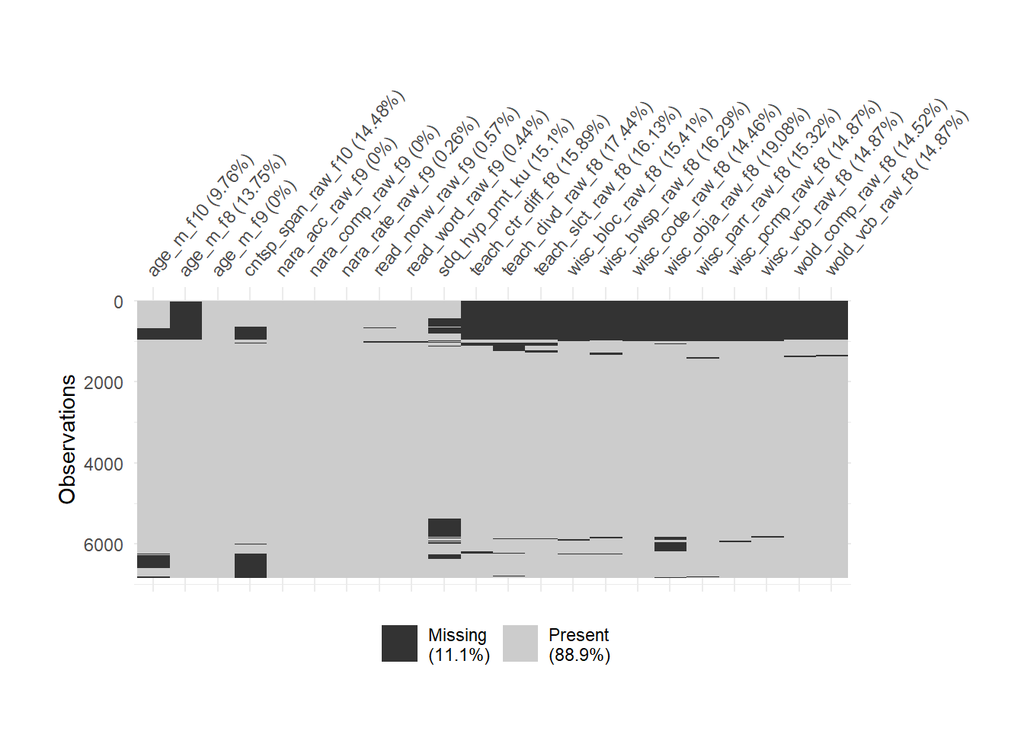

```r
# Prevalence
missing_prev <- wp1_data %>%
  select(-all_of(c(other, missingness, "yp_id"))) %>%
  select(order(colnames(.))) %>%
  vis_miss(cluster = TRUE)

missing_prev +
  theme(axis.text.x = element_text(angle = 50),
  plot.margin = unit(c(1, 3, 1, 1), "cm"))
```

```r
#ggsave("../output/figures/missingness/WP1_missingness.png")
```

### Structure

Use two types of test to examine whether data is likely MCAR. Little’s (1988) MCAR test examines whether variable means differ between missing data patterns. Jamshidian & Jalal’s (2010) test examines whether the variances and covariances differ between missing data patterns.

```r
# Little's MCAR test - FIXED
# R package "naniar" states in help file: Code is adapted from LittleMCAR() in the *now-orphaned* BaylorEdPsych package: https://rdrr.io/cran/BaylorEdPsych/man/LittleMCAR.html. Some of code is adapted from Eric Stemmler - https://web.archive.org/web/20201120030409/https://stats-bayes.com/post/2020/08/14/r-function-for-little-s-test-for-data-missing-completely-at-random/ using Maximum likelihood estimation from norm.
# Problem related to the packages pulled from CRAN, never a good sign. I looked at the function and it had problem with mlest()

missingness_little <- wp1_data %>%
  dplyr::select(-all_of(c(other, "yp_id"))) %>%
  dplyr::select(where(is.numeric)) %>%
  naniar::mcar_test()
#
 print(cat("\nLITTLE'S TEST \nchi.square:", missingness_little$statistic, "\ndf:", missingness_little$df, "\np = ", missingness_little$p.value))
```

```
##
## LITTLE'S TEST
## chi.square: 9823.155
## df: 6001
## p =  0NULL
```

```r
# Jamshidian & Jalal (2010) MCAR test
missingness_jj <- wp1_data %>%
  select(-all_of(c(other))) %>%
  select(where(is.numeric)) %>%
  TestMCARNormality()

print(cat("\nJAMSHIDIAN & JALAL MCAR TEST
          \nNumber of missing data patterns: ", missingness_jj$g,
          "\nHawkins Test of normality and homoscedasticity: ", round(missingness_jj$pvalcomb, 5),
          "\nP-value for non-paramatric test of homoscedasticity: ", round(missingness_jj$pnormality, 5)))
```

```
##
## JAMSHIDIAN & JALAL MCAR TEST
##
## Number of missing data patterns:  53
## Hawkins Test of normality and homoscedasticity:  0
## P-value for non-paramatric test of homoscedasticity:  0NULL
```

The two tests indicate that the data are not likely missing completely at random (MCAR).

### Predictors of missingness

Given the assessments are all taken from assessments close in time, we did not anticipate structured missingness in these data. Create plots to examine potential predictors of missingness for each variable (to inspect separately).

```r
# Create updated list of pre-registered variables (incorporating new vars created above)
prereg_vars <- names(wp1_data) %>%
  setdiff(c(missingness, other))

# For each of the variables used in a main analysis...
for (key_var in prereg_vars){

  # Create data frame with selected variable marked for missingness, remove irrelevant columns
  data <- wp1_data %>%
    select(-all_of(other), sex) %>%  # select predictor variables
    mutate(is_missing = ifelse(is.na(get(key_var)) == TRUE, 1, 0)) %>%  # format variable as missing/not
    select(-c(key_var))

  # If no missing data, print statement
  if (sum(data$is_missing) == 0) {
      print(paste0("No missing values for variable ", key_var))

  # Else if missing data present...
  } else {

    # Summarise amount different
    percent_miss <- round(mean(data$is_missing)*100, 2)

    # Create dataframe for plotting continuous predictors
    cont_data <- data %>%
      select(c(which(sapply(., is.numeric)), "is_missing")) %>%
      pivot_longer(cols = -is_missing, names_to = "var_name", values_to = "var_val")

    # Plot faceted boxplots for each continuous predictor of missingness
    cont_plot <- ggplot(cont_data, aes(x = as.factor(is_missing), y = var_val)) +
      theme_bw() +
      geom_boxplot() +
      theme(strip.text.x = element_text(size = 8)) +
      facet_wrap(~ var_name, ncol = 5, scales = "free") +
      labs(title = "Continuous predictors",
           x = "", y = "") +
      theme(plot.title = element_text(size = 12, margin = margin(0, 0, 5, 0)))

    # Create dataframe for plotting factorial predictors
    fact_data <- data %>%
      select(c(which(sapply(., is.factor)), "is_missing")) %>%

      # Recode values for each one so that meaningful
      mutate(ethn_c = recode(ethn_c, `1` = "white", `2` = "non-white"),
             m_edu_c = recode(m_edu_c, `0` = "None", `1` = "CSE", `2` = "Vocational",
                              `3` = "O level", `4` = "A level", `5` = "Degree"),
             m_home_a = recode(m_home_a, `0` = "mortgaged", `1` = "owned", `2` = "council rent",
                               `3` = "priv rent (furn)", `4` = "priv rent (unfurn)", `5` = "HA rented",
                               `6` = "other", `9` = "don't know" ),
             sex = recode(sex, `1` = "male", `2` = "female")) %>%

      pivot_longer(cols = -is_missing, names_to = "var_name", values_to = "var_val") %>%
      group_by(var_name, var_val, is_missing) %>%
      count() %>%
      ungroup() %>%
      group_by(var_name, is_missing) %>%
      arrange(is_missing, var_name) %>%
      mutate(proportion = prop.table(n))

    # Plot stacked bar chart with proportions for each one (separately as different values)
    fact_mult <- lapply(split(fact_data, fact_data$var_name), function(i){
      ggplot(i, aes(x = as.factor(is_missing), y = proportion, fill = var_val)) +
      theme_bw() +
      geom_col(position = "fill")  +
      scale_y_continuous(limits = c(0, 1), expand = c(0,0)) +
      theme(legend.position = "bottom",
            legend.title = element_blank(),
            legend.key.size = unit(0.3, "cm"),
            legend.spacing.y = unit(0, "cm"),
            legend.margin=margin(0,0,0,0),
            legend.box.margin=margin(-20,-20,0 ,-20),
            legend.text = element_text(size = 8)) +
      guides(fill = guide_legend(ncol = 2, nrow = 4, byrow = FALSE)) +
      facet_wrap(~ var_name, ncol = 1, scales = "free") +
      labs(x = "", y = "", fill = "")})

    # ... combine discrete predictors into single plot
    fact_plot_a <- plot_grid(plotlist = fact_mult, nrow = 1, labels = levels(fact_data$var_name))

    # ... create and add title for discrete predictor plots
    fact_title <- ggdraw() +
      draw_label(paste0("Discrete predictors"),
                 size = 12,
                 x = 0.06, hjust = 0)

    fact_plot_b <- plot_grid(fact_title, fact_plot_a, ncol = 1,
                      rel_heights = c(0.08, 1))

    # Combine continuous and discrete plots into single figure

    ### Create title
    title <- ggdraw() +
      draw_label(paste0("Missingness in ", key_var, " (", percent_miss, "%)"),
                 fontface = "bold",
                 size = 18,
                 x = 0.5)

    ### Create subtitle with plot info
    plot_info <- ggdraw() +
      draw_label("0 = data available; 1 = data missing",
                 fontface = "italic",
                 size = 12,
                 x = 0.5)

    ### Combine plots
    comb_plot <- plot_grid(cont_plot, fact_plot_b, nrow = 2, rel_heights = c(1, 0.3))

    full_fig <- plot_grid(title, plot_info, comb_plot, ncol = 1,
                      rel_heights = c(0.03, 0.02, 1))

    ### Create file name and save
    fig_name <- paste0("../output/figures/missingness/", key_var, ".png")
    ggsave(fig_name, full_fig, height = 12, width = 9)
  }
}
```

```
## [1] "No missing values for variable age_m_f9"
```

```
## [1] "No missing values for variable nara_acc_raw_f9"
## [1] "No missing values for variable nara_comp_raw_f9"
```

We had originally planned to examine whether missingness in which variable was predicted by every other variable in the above selection, but given that the vast majority of missingness is at the clinic level (i.e., there are significant contingencies between missingness for tasks administered at the same point in the study), the regression models had problems with separation.

Given that the majority of missingness was at the level of the data collection wave, we instead tested for predictors of data availability at each wave using the selected variables from all other collection waves. For ease of interpretation, we tested continuous predictors in using the binomial regressions as planned, but used chi-squared tests for the discrete predictors (testing for overall independence, rather than specifying numerous contrasts).

```r
# Select one variable per wave (not f9, as selected on this basis)
wave_avail <- c("age_m_f8", "age_m_f10", "age_m_ku")

# Continuous predictors

### Create data frame for storing significant predictors
cont_pred <- data.frame(missing_val = as.character(), predictor = as.character(), estimate = as.numeric(), std.error = as.numeric(), statistic = as.numeric(), p.value = as.numeric(), p.holm = as.numeric())

### For the variable selected from each data collection wave
for (var in wave_avail){

  # Extract data collection wave
  wave <- str_extract(var, "[^_]+$")

  # List all other measures from same wave for removal
  same_wave <- str_subset(prereg_vars, wave)

  # Create data frame with selected variable marked for missingness, remove variables from same wave
  data <- wp1_data %>%
    select(-all_of(other), sex, age_m_ku) %>%
    mutate(is_missing = ifelse(is.na(get(var)) == TRUE, 1, 0)) %>%
    select(c(which(sapply(., is.numeric)), is_missing)) %>%
    select(-all_of(same_wave))

  # If no missing data, print statement
  if (sum(data$is_missing) == 0) {
      print(paste0("No missing values for variable ", var))

  # Else if missing data present...
  } else {

      # Test every other variable as a predictor
      missing_model <- glm(is_missing ~ ., family = binomial("logit"), data = data)
      tidy_model <- tidy(missing_model) %>%  # format output
        mutate(missing_val = var, p.adjust = p.adjust(p.value, "holm")) %>%
        rename(predictor = term) %>%
        select(missing_val, predictor, estimate, std.error, statistic, p.value, p.adjust)

      # If any of the values are significant, print output labelled with predictor and variable
      if(any(tidy_model$p.value < .05)) {
        print(paste0("Potential predictors (non-corrected) of missing values for variable  ", var))

        # Append significant predictors to missing data table
        sig_vals <- tidy_model %>%
          filter(p.value < .05)
        cont_pred <- rbind(cont_pred, sig_vals) %>%
          mutate_at(3:7, round, 3)

      # Otherwise print that no significant predictors were found
      } else {
        print(paste0("No significant predictors of missing values found for variable ", var))
      }
  }
}
```

```
## [1] "Potential predictors (non-corrected) of missing values for variable  age_m_f8"
## [1] "Potential predictors (non-corrected) of missing values for variable  age_m_f10"
## [1] "No significant predictors of missing values found for variable age_m_ku"
```

```r
# Also inspect correlation matrix
corr_matrix <- wp1_data %>%
    select(-all_of(other), sex, age_m_ku) %>%
    select(c(which(sapply(., is.numeric)))) %>%
  cor(use = "pairwise.complete.obs") %>%
  round(2)
corr_matrix[abs(corr_matrix) < 0.4] <- NA   # set threshold

# Discrete predictors

### Create data frame for storing significant predictors
disc_pred <- data.frame(missing_val = as.character(), predictor = as.character(),
                        chisq.stat = as.numeric(), df = as.numeric(), p.value = as.numeric())

### For the variable selected in each collection wave
for (var in wave_avail){

  # Create data frame with selected variable marked for missingness, remove variables from same wave
  data <- wp1_data %>%
    select(c(which(sapply(., is.factor)), var)) %>%
    mutate(is_missing = as.factor(ifelse(is.na(get(var)) == TRUE, 1, 0))) %>%
    select(-var) %>%
    mutate(ethn_c = recode(ethn_c, `1` = "white", `2` = "non-white"),
       m_edu_c = recode(m_edu_c, `0` = "None", `1` = "CSE", `2` = "Vocational",
                        `3` = "O level", `4` = "A level", `5` = "Degree"),
       m_home_a = recode(m_home_a, `0` = "mortgaged", `1` = "owned", `2` = "council rent",
                         `3` = "priv rent (furn)", `4` = "priv rent (unfurn)", `5` = "HA rented",
                         `6` = "other", `9` = "don't know"),
       sex = recode(sex, `1` = "male", `2` = "female"))

  # List discrete variables
  disc_vars <- names(data)[names(data) != "is_missing"]

  # For each discrete predictor
  for (pred_var in disc_vars){

    # Select relevant two variables for chisquare test (missing data variable and predictor)
    test_vars <- data %>%
      select(pred_var, is_missing)

    # Conduct chisquare test, format, and append to output
    chisq <- chisq.test(table(test_vars))
    new_row <- data.frame(var, pred_var, chisq$statistic, chisq$parameter, chisq$p.value)
    disc_pred <- rbind(disc_pred, new_row)
  }
}

# Print continuous predictors of missingness
cont_pred %>%
  arrange(predictor)
```

```
## # A tibble: 8 x 7
##   missing_val predictor        estimate std.error statistic p.value p.adjust
##   <chr>       <chr>               <dbl>     <dbl>     <dbl>   <dbl>    <dbl>
## 1 age_m_f8    (Intercept)       -30.3       4.76      -6.37   0        0
## 2 age_m_f10   (Intercept)       -33.2       6.43      -5.16   0        0
## 3 age_m_f8    age_m_f10           0.062     0.021      2.99   0.003    0.031
## 4 age_m_f10   age_m_f8            0.071     0.022      3.18   0.001    0.036
## 5 age_m_f8    age_m_f9            0.116     0.016      7.22   0        0
## 6 age_m_f10   age_m_f9            0.093     0.021      4.36   0        0
## 7 age_m_f8    m_age_birth        -0.06      0.014     -4.39   0        0
## 8 age_m_f8    nara_comp_raw_f9   -0.059     0.014     -4.26   0        0
```

```r
# Print discrete predictors of missingness
disc_pred %>%
  as.data.frame() %>%
  rownames_to_column() %>%
  select(pred_var:chisq.p.value) %>%
  filter(chisq.p.value < .05) %>%
  mutate(chisq.p.value = round(chisq.p.value, 5)) %>%
  arrange(pred_var)
```

```
##   pred_var chisq.statistic chisq.parameter chisq.p.value
## 1   ethn_c        17.79498               1       0.00002
## 2   ethn_c         6.80226               1       0.00910
## 3   ethn_c        16.56532               1       0.00005
## 4  m_edu_c       147.54486               4       0.00000
## 5  m_edu_c        37.18697               4       0.00000
## 6  m_edu_c       123.05395               4       0.00000
## 7 m_home_a       108.53461               6       0.00000
## 8 m_home_a        57.99488               6       0.00000
## 9 m_home_a        91.84174               6       0.00000
```

```r
# Check whether any variables not included in the analysis are good predictors of values that might be missing (>.4)
corr_matrix %>%
  as.data.frame() %>%
  rownames_to_column() %>%
  filter(rowname %in% prereg_vars) %>%
  select(any_of(c("rowname", missingness)))
```

```
##               rowname wght_birth gest_birth m_age_birth mtcq_vcb_raw_kg
## 1            age_m_f8         NA         NA          NA              NA
## 2            age_m_f9         NA         NA          NA              NA
## 3    read_word_raw_f9         NA         NA          NA              NA
## 4    read_nonw_raw_f9         NA         NA          NA              NA
## 5     nara_acc_raw_f9         NA         NA          NA              NA
## 6    nara_comp_raw_f9         NA         NA          NA              NA
## 7    wold_comp_raw_f8         NA         NA          NA              NA
## 8           age_m_f10         NA         NA          NA              NA
## 9    nara_rate_raw_f9         NA         NA          NA              NA
## 10    wisc_vcb_raw_f8         NA         NA          NA              NA
## 11   wisc_pcmp_raw_f8         NA         NA          NA              NA
## 12   wisc_code_raw_f8         NA         NA          NA              NA
## 13   wisc_parr_raw_f8         NA         NA          NA              NA
## 14   wisc_bloc_raw_f8         NA         NA          NA              NA
## 15   wisc_obja_raw_f8         NA         NA          NA              NA
## 16   wisc_bwsp_raw_f8         NA         NA          NA              NA
## 17 cntsp_span_raw_f10         NA         NA          NA              NA
## 18  teach_slct_raw_f8         NA         NA          NA              NA
## 19  teach_divd_raw_f8         NA         NA          NA              NA
## 20    sdq_hyp_prnt_ku         NA         NA          NA              NA
## 21    wold_vcb_raw_f8         NA         NA          NA              NA
## 22  teach_ctr_diff_f8         NA         NA          NA              NA
```

Document missingness for all variables in a table.

```r
# Clinic missing
clinic_miss <- wp1_data %>%
  select(all_of(c(wave_avail, "age_m_f9"))) %>%
  pivot_longer(cols = everything(), names_to = "variable", values_to = "value") %>%
  group_by(variable) %>%
  summarise(n_avail = sum(!is.na(value)), n_all = n(), mean = mean(value, na.rm = TRUE)) %>%
  mutate(wave = str_extract(variable, "[^_]+$"),
         wave_miss = round((1-n_avail/n_all)*100, 2)) %>%
  relocate(wave, .after = variable) %>%
  mutate(wave = fct_reorder(wave, mean)) %>%
  #mutate(wave = fct_relevel(wave, "ku", "f8", "f9", "f10")) %>%
  arrange(wave) %>%
  select(-n_all, -variable, -n_avail, -mean)

# Variable missing
var_miss <- wp1_data %>%
  select(all_of(prereg_vars), -all_of(c(wave_avail, "age_m_f9"))) %>%
  pivot_longer(cols = everything(), names_to = "variable", values_to = "value") %>%
  group_by(variable) %>%
  summarise(n_avail = sum(!is.na(value)), n_all = n()) %>%
  mutate(wave = str_extract(variable, "[^_]+$"),
         overall_miss = round((1-n_avail/n_all)*100, 2)) %>%
  arrange(wave, variable) %>%
  select(-n_all)

# Total missing table (can be written out for Word table)
missing <- left_join(clinic_miss, var_miss, by = c("wave")) %>%
  mutate(task_miss = overall_miss-wave_miss) %>%
  set_names(c("Data collection wave (% missing)", "Wave-level missingness (%)", "Measure", "Data availability (n)", "Total missingness (%)", "Measure-specific missingness (%)"))
write.csv(missing, "../output/tables/proportion_missingness.csv", row.names = FALSE)

# Formatted table
missing %>%
  select(-"Wave-level missingness (%)") %>%
  mutate("Data collection wave (% missing)" = "") %>%
  kable() %>%
  kable_classic()  %>%
  pack_rows(paste0("Focus @ 8 (", clinic_miss[1,2], "%)"), 1, 12) %>%
  pack_rows(paste0("Parental Questionnaire (KU) (", clinic_miss[2,2], "%)"), 13, 13) %>%
  pack_rows(paste0("Focus @ 9 (", clinic_miss[3,2], "%)"), 14, 18) %>%
  pack_rows(paste0("Focus @ 10 (", clinic_miss[4, 2], "%)"), 19, 19)
```

| Data collection wave (% missing) | Measure | Data availability (n) | Total missingness (%) | Measure-specific missingness (%) |
| --- | --- | --- | --- | --- |
| **Focus @ 8 (13.75%)** |  |  |  |  |
|  | teach_ctr_diff_f8 | 5758 | 15.89 | 2.14 |
|  | teach_divd_raw_f8 | 5652 | 17.44 | 3.69 |
|  | teach_slct_raw_f8 | 5742 | 16.13 | 2.38 |
|  | wisc_bloc_raw_f8 | 5791 | 15.41 | 1.66 |
|  | wisc_bwsp_raw_f8 | 5731 | 16.29 | 2.54 |
|  | wisc_code_raw_f8 | 5856 | 14.46 | 0.71 |
|  | wisc_obja_raw_f8 | 5540 | 19.08 | 5.33 |
|  | wisc_parr_raw_f8 | 5797 | 15.32 | 1.57 |
|  | wisc_pcmp_raw_f8 | 5828 | 14.87 | 1.12 |
|  | wisc_vcb_raw_f8 | 5828 | 14.87 | 1.12 |
|  | wold_comp_raw_f8 | 5852 | 14.52 | 0.77 |
|  | wold_vcb_raw_f8 | 5828 | 14.87 | 1.12 |
| **Parental Questionnaire (KU) (13.89%)** |  |  |  |  |
|  | sdq_hyp_prnt_ku | 5812 | 15.10 | 1.21 |
| **Focus @ 9 (0%)** |  |  |  |  |
|  | nara_acc_raw_f9 | 6846 | 0.00 | 0.00 |
|  | nara_comp_raw_f9 | 6846 | 0.00 | 0.00 |
|  | nara_rate_raw_f9 | 6828 | 0.26 | 0.26 |
|  | read_nonw_raw_f9 | 6807 | 0.57 | 0.57 |
|  | read_word_raw_f9 | 6816 | 0.44 | 0.44 |
| **Focus @ 10 (9.76%)** |  |  |  |  |
|  | cntsp_span_raw_f10 | 5855 | 14.48 | 4.72 |

There is structural missingness according to socio-demographic variables that are not already included in our analysis plans. These can typically be incorporated as auxiliary variables, although require treating as continuous or binary dummy variables for implementation in mplus. Thus, we re-binned the maternal education and home ownership variables according to previous analyses of ALSPAC data (e.g., Roulstone et al., 2011; Gibson et al., 2020)

```r
wp1_data <- wp1_data %>%
    mutate(m_home_own = recode(m_home_a, `0` = 1, `1` = 1,  # mortgaged or owned = 1
                             `2` = 0, `3` = 0, `4` = 0,     # all other = 0
                             `5` = 0, `6` = 0, `9` = 0),
         m_edu_alev = recode(m_edu_c, `0` = 0,
                             `1` = 0, `2` = 0, `3` = 0,     # CSE/Vocational/O-level = 0
                             `4` = 1, `5` = 1),             # A-level/degree = 1
         ethn_white = recode(ethn_c, `1` = 1, `2` = 0),     # recode into interpretable dummy variables
         sex_fem =  recode(sex, `1` = 0, `2` = 1) )         # recode into interpretable dummy variables
```

Unfortunately, auxiliary variables are not easy to incorporate into mixture models without changing the interpretation of the model. Given that a number of the variables that predicted missingness are already included in our analyses (age at clinic attendance, comprehension score), we tested whether remaining socio-demographic variables predicted missingness above and beyond those variables already included in our analyses.

```r
# RESEARCH QUESTION 1 - Simple View of Reading

## Data collection wave F@8
### Create dataset with complete predictors, with woldcomp coded for missingness
rq1_test <- wp1_data %>%
  mutate(is_missing = is.na(wold_comp_raw_f8)) %>%
  select(is_missing, nara_comp_raw_f9, nara_acc_raw_f9, read_word_raw_f9 , read_nonw_raw_f9 , age_m_f8 , age_m_f9 ,
         m_home_own, m_edu_alev , ethn_white , sex_fem , m_age_birth) %>%
  drop_na()

### Use planned variables to predict missingness
mod1 <- glm(is_missing ~ nara_comp_raw_f9 + nara_acc_raw_f9 + read_word_raw_f9 + read_nonw_raw_f9 + age_m_f8 + age_m_f9,
            data = rq1_test, family = "binomial")

### Add additional demographic variables
mod2 <- update(mod1, ~. + m_home_own + m_edu_alev + ethn_white + m_age_birth)

### Test whether model fit is significantly improved by their inclusion
anova(mod1, mod2, test = "Chisq")
```

```
## Analysis of Deviance Table
##
## Model 1: is_missing ~ nara_comp_raw_f9 + nara_acc_raw_f9 + read_word_raw_f9 +
##     read_nonw_raw_f9 + age_m_f8 + age_m_f9
## Model 2: is_missing ~ nara_comp_raw_f9 + nara_acc_raw_f9 + read_word_raw_f9 +
##     read_nonw_raw_f9 + age_m_f8 + age_m_f9 + m_home_own + m_edu_alev +
##     ethn_white + m_age_birth
##   Resid. Df Resid. Dev Df Deviance Pr(>Chi)
## 1      5263     491.45
## 2      5259     488.55  4   2.9007   0.5746
```

```r
# RESEARCH QUESTION 2 - Heterogeneity in cognitive profiles

## Data collection wave KU (SDQ questionnaire)
### Create dataset with complete predictors, with the SDQ coded for missingness
rq2a_test <- wp1_data %>%
  mutate(is_missing = is.na(sdq_hyp_prnt_ku)) %>%
  select(-contains("_std_"), -yp_id, -cidB3153, -qlet, -sex, -m_home_a, -m_edu_c, -ethn_c, -wght_birth, -gest_birth,
         -mtcq_vcb_raw_kg, age_m_ku, -nara_npass_f9, -sdq_hyp_prnt_ku) %>%
  drop_na()

### Use planned variables to predict missingness
mod1 <- glm(is_missing ~  age_m_f8  +  age_m_f9 + read_word_raw_f9 + read_nonw_raw_f9 + nara_acc_raw_f9 + nara_comp_raw_f9 +
              wold_comp_raw_f8 +  age_m_f10  + nara_rate_raw_f9 + wisc_vcb_raw_f8  + wisc_pcmp_raw_f8 + wisc_code_raw_f8  +
              wisc_parr_raw_f8 + wisc_bloc_raw_f8 + wisc_obja_raw_f8 + wisc_bwsp_raw_f8 + cntsp_span_raw_f10 + teach_slct_raw_f8  +
              teach_divd_raw_f8 + wold_vcb_raw_f8 +  teach_ctr_diff_f8, data = rq2a_test, family = "binomial")

### Add additional demographic variables
mod2 <- update(mod1, ~. + m_home_own + m_edu_alev + ethn_white + m_age_birth)

### Test whether model fit is significantly improved by their inclusion
anova(mod1, mod2, test = "Chisq")
```

```
## Analysis of Deviance Table
##
## Model 1: is_missing ~ age_m_f8 + age_m_f9 + read_word_raw_f9 + read_nonw_raw_f9 +
##     nara_acc_raw_f9 + nara_comp_raw_f9 + wold_comp_raw_f8 + age_m_f10 +
##     nara_rate_raw_f9 + wisc_vcb_raw_f8 + wisc_pcmp_raw_f8 + wisc_code_raw_f8 +
##     wisc_parr_raw_f8 + wisc_bloc_raw_f8 + wisc_obja_raw_f8 +
##     wisc_bwsp_raw_f8 + cntsp_span_raw_f10 + teach_slct_raw_f8 +
##     teach_divd_raw_f8 + wold_vcb_raw_f8 + teach_ctr_diff_f8
## Model 2: is_missing ~ age_m_f8 + age_m_f9 + read_word_raw_f9 + read_nonw_raw_f9 +
##     nara_acc_raw_f9 + nara_comp_raw_f9 + wold_comp_raw_f8 + age_m_f10 +
##     nara_rate_raw_f9 + wisc_vcb_raw_f8 + wisc_pcmp_raw_f8 + wisc_code_raw_f8 +
##     wisc_parr_raw_f8 + wisc_bloc_raw_f8 + wisc_obja_raw_f8 +
##     wisc_bwsp_raw_f8 + cntsp_span_raw_f10 + teach_slct_raw_f8 +
##     teach_divd_raw_f8 + wold_vcb_raw_f8 + teach_ctr_diff_f8 +
##     m_home_own + m_edu_alev + ethn_white + m_age_birth
##   Resid. Df Resid. Dev Df Deviance Pr(>Chi)
## 1      3632     441.70
## 2      3628     440.96  4  0.73708   0.9467
```

```r
## Data collection wave F@10
rq2b_test <- wp1_data %>%
  mutate(is_missing = is.na(cntsp_span_raw_f10)) %>%
  select(-contains("_std_"), -yp_id, -cidB3153, -qlet, -sex, -m_home_a, -m_edu_c, -ethn_c, -wght_birth, -gest_birth,
         -mtcq_vcb_raw_kg, age_m_ku, -nara_npass_f9, -cntsp_span_raw_f10) %>%
  drop_na()

### Use planned variables to predict missingness
mod1 <- glm(is_missing ~  age_m_f8  +  age_m_f9 + read_word_raw_f9 + read_nonw_raw_f9 + nara_acc_raw_f9 + nara_comp_raw_f9 +
              wold_comp_raw_f8 +  age_m_f10  + nara_rate_raw_f9 + wisc_vcb_raw_f8  + wisc_pcmp_raw_f8 + wisc_code_raw_f8  +
              wisc_parr_raw_f8 + wisc_bloc_raw_f8 + wisc_obja_raw_f8 + wisc_bwsp_raw_f8 + sdq_hyp_prnt_ku + teach_slct_raw_f8  +
              teach_divd_raw_f8 + wold_vcb_raw_f8 +  teach_ctr_diff_f8, data = rq2b_test, family = "binomial")

### Add additional demographic variables
mod2 <- update(mod1, ~. + m_home_own + m_edu_alev + ethn_white + m_age_birth)

### Test whether model fit is significantly improved by their inclusion
anova(mod1, mod2, test = "Chisq")
```

```
## Analysis of Deviance Table
##
## Model 1: is_missing ~ age_m_f8 + age_m_f9 + read_word_raw_f9 + read_nonw_raw_f9 +
##     nara_acc_raw_f9 + nara_comp_raw_f9 + wold_comp_raw_f8 + age_m_f10 +
##     nara_rate_raw_f9 + wisc_vcb_raw_f8 + wisc_pcmp_raw_f8 + wisc_code_raw_f8 +
##     wisc_parr_raw_f8 + wisc_bloc_raw_f8 + wisc_obja_raw_f8 +
##     wisc_bwsp_raw_f8 + sdq_hyp_prnt_ku + teach_slct_raw_f8 +
##     teach_divd_raw_f8 + wold_vcb_raw_f8 + teach_ctr_diff_f8
## Model 2: is_missing ~ age_m_f8 + age_m_f9 + read_word_raw_f9 + read_nonw_raw_f9 +
##     nara_acc_raw_f9 + nara_comp_raw_f9 + wold_comp_raw_f8 + age_m_f10 +
##     nara_rate_raw_f9 + wisc_vcb_raw_f8 + wisc_pcmp_raw_f8 + wisc_code_raw_f8 +
##     wisc_parr_raw_f8 + wisc_bloc_raw_f8 + wisc_obja_raw_f8 +
##     wisc_bwsp_raw_f8 + sdq_hyp_prnt_ku + teach_slct_raw_f8 +
##     teach_divd_raw_f8 + wold_vcb_raw_f8 + teach_ctr_diff_f8 +
##     m_home_own + m_edu_alev + ethn_white + m_age_birth
##   Resid. Df Resid. Dev Df Deviance Pr(>Chi)
## 1      3758     1323.0
## 2      3754     1317.8  4   5.2203   0.2654
```

Any structure in missingness is sufficiently accounted for by variables already in the model. Thus, the data meet the assumption of missing at random, and analyses can proceed using FIML.

# Split sample and save out data

Create subsamples to be used for RQ1 initial class enumeration process and subsequent validation.

```r
# Repeat seed above for reproducibility
set.seed(25052021)

# Create numeric ID variable for working with mplus, remove unnecessary variables and tidy order
wp1_tidy <- wp1_data %>%

  # Select and reorder variables
  select(-all_of(c(missingness, "sex")), m_age_birth,) %>%
  relocate(c(yp_id, cidB3153, qlet, sex_fem), .before = 1) %>%
  relocate(age_m_f10, .after = age_m_f9) %>%
  relocate(teach_ctr_diff_f8, .after = teach_divd_raw_f8) %>%
  relocate(wold_vcb_raw_f8, .after = wisc_vcb_raw_f8)

# Create exploratory/calibration dataset
sampleA <- wp1_tidy %>%
  sample_frac(.50)

# Create confirmatory/validation dataset
sampleB <- wp1_tidy %>%
  anti_join(sampleA, by = "yp_id")

# Check
sampleA$yp_id[(sampleA$yp_id %in% sampleB$yp_id)]
```

```
## character(0)
```

```r
sampleB$yp_id[(sampleB$yp_id %in% sampleA$yp_id)]
```

```
## character(0)
```

```r
(nrow(sampleA) + nrow(sampleB)) == nrow(wp1_tidy)
```

```
## [1] TRUE
```

```r
# Save
write.csv(sampleA, "../data/processed/WP1_data_subA.csv", row.names = FALSE)
write.csv(sampleB, "../data/processed/WP1_data_subB.csv", row.names = FALSE)
write.csv(wp1_tidy, "../data/processed/WP1_data_all.csv", row.names = FALSE)
```